# Udacity 651 PS5 - GapMinder

## Problem set 5 - gapminder

### Using data set Aged 65+ labour force participation rate (%)

For output of this RMD file (including graphs):

- http://github.crookster.org/SR_Foundations_DS_Fall_2015/UD651/L5/lesson5_gapminder.html

Getting started

```r
library(ggplot2)
library(dplyr)
library(gridExtra)
library(reshape2)

setwd("~/projects/Classes/FoundationsOfDataScience_sliderule/github/UD651/L5")
df = read.csv ("indicator_t_above_65_labour_to_pop_percent_data_fixed.csv", header = TRUE)

# head(df)
colnames(df) <- c("country", 1980:2007)
#str(df)
```

### transform the data into a long format

```r
#install.packages("tidyr")
library(tidyr)

ldf <- gather(df, "year", "percentage", 2:29)

# want the years to be numeric instead of factor?
ldf$year_numeric <- with(ldf, as.numeric(levels(year))[year])
# head(ldf)
str(ldf)
```

```
## 'data.frame':    5292 obs. of  4 variables:
##  $ country     : Factor w/ 189 levels "Afghanistan",..: 1 2 3 4 5 6 7 8 9 10 ...
##  $ year        : Factor w/ 28 levels "1980","1981",..: 1 1 1 1 1 1 1 1 1 1 ...
##  $ percentage  : num  28.5 10.2 17.5 54.7 11.2 ...
##  $ year_numeric: num  1980 1980 1980 1980 1980 1980 1980 1980 1980 1980 ...
```

### dist of percentages across all years and country

```
## stat_bin: binwidth defaulted to range/30. Use 'binwidth = x' to adjust this.
```

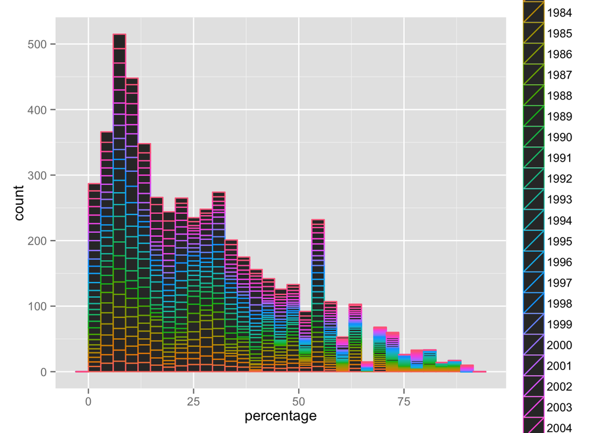

```r
# layer all years
ggplot(aes(x = percentage), data = ldf) +
  geom_histogram(aes(color = year))
```

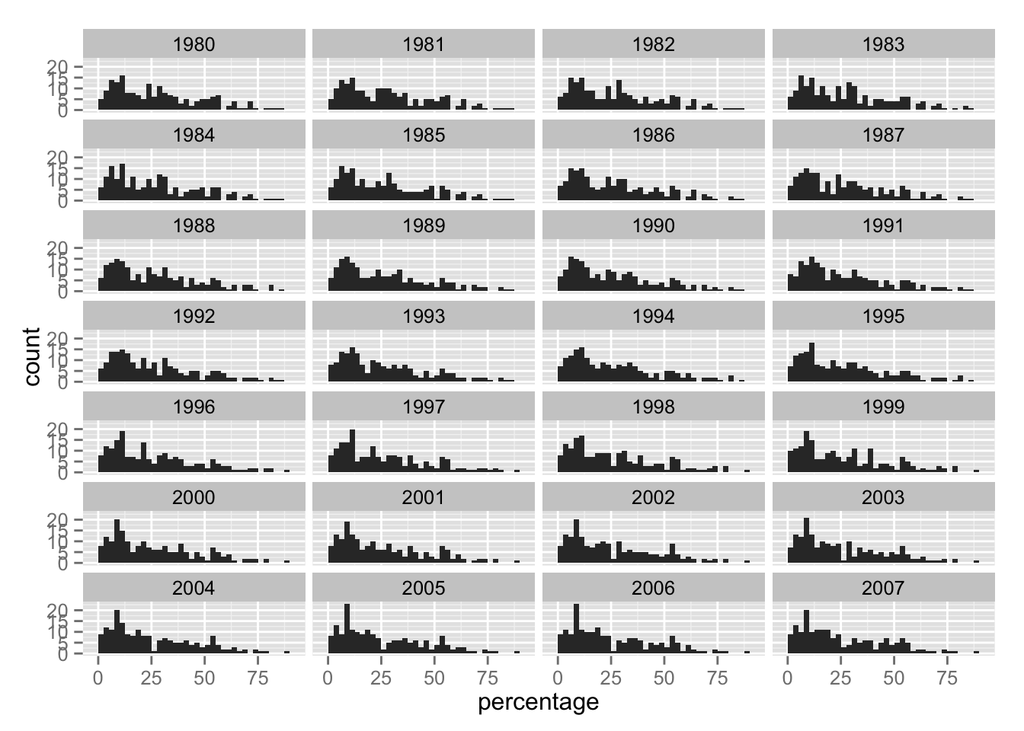

```r
# separate each year
ggplot(aes(x = percentage), data = ldf) +
  geom_histogram(binwidth = 2.5) +
  facet_wrap( ~ year, ncol = 4)
```

### percentage trends by country

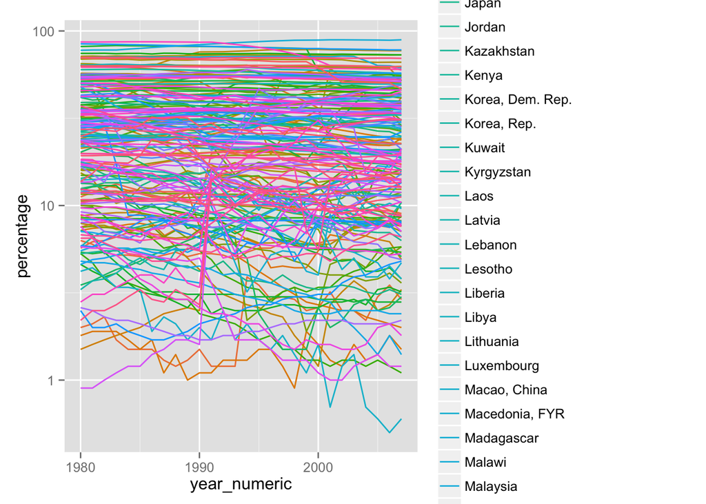

```r
## trend by country - line graph over time
#ggplot(aes(x = year_numeric, y = percentage), data = ldf) +
#  geom_line(aes(color = country))

# same  on semi-log scale, to avoid the bunching at the lower percentages
ggplot(aes(x = year_numeric, y = percentage), data = ldf) +
  geom_line(aes(color = country)) +
  scale_y_log10()
```

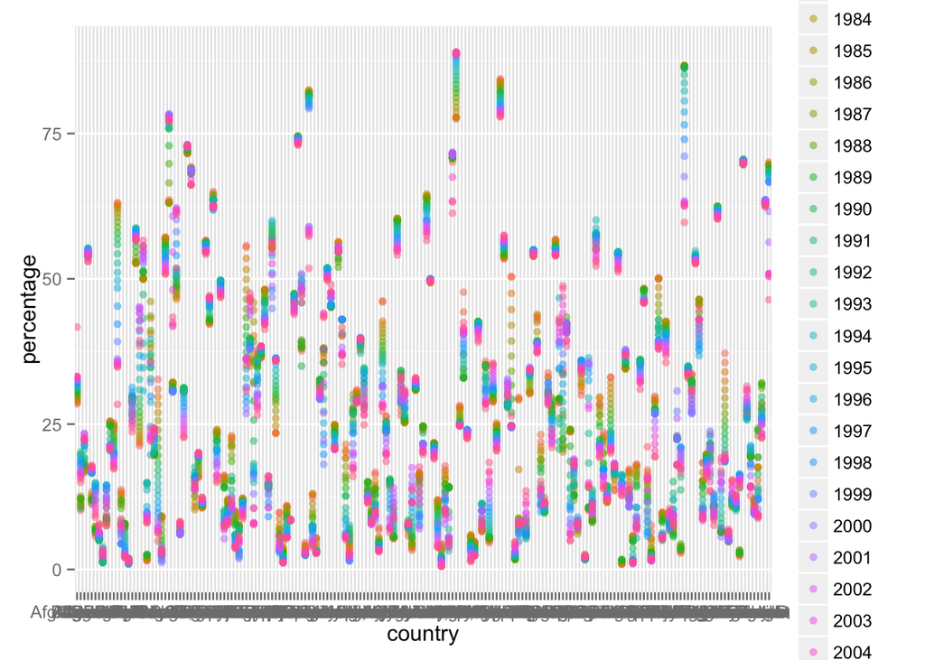

```r
# another trend by country graph
ggplot(aes(x = country, y = percentage), data = ldf) +
  geom_point(aes(color = year), alpha = 5/10) +
  scale_fill_brewer(type = "div")
```

#### Comments:

in 1990, there were a number of increases in a few countries; were these due to regional macroeconomic effects? would like to cluster geographically.

general trends at a glance seem to show that there is steady or decline in employment rate, with a few exceptions, but there is really too much noise to see for sure.

### percentage trends by country

```r
ldf.pct_by_country <- ldf %.%
  group_by(country) %.%
  summarise(pct_mean = mean(percentage),
            pct_median = median(percentage),
            n = n()) %.%
   arrange(country)
#head(ldf.pct_by_country)
```

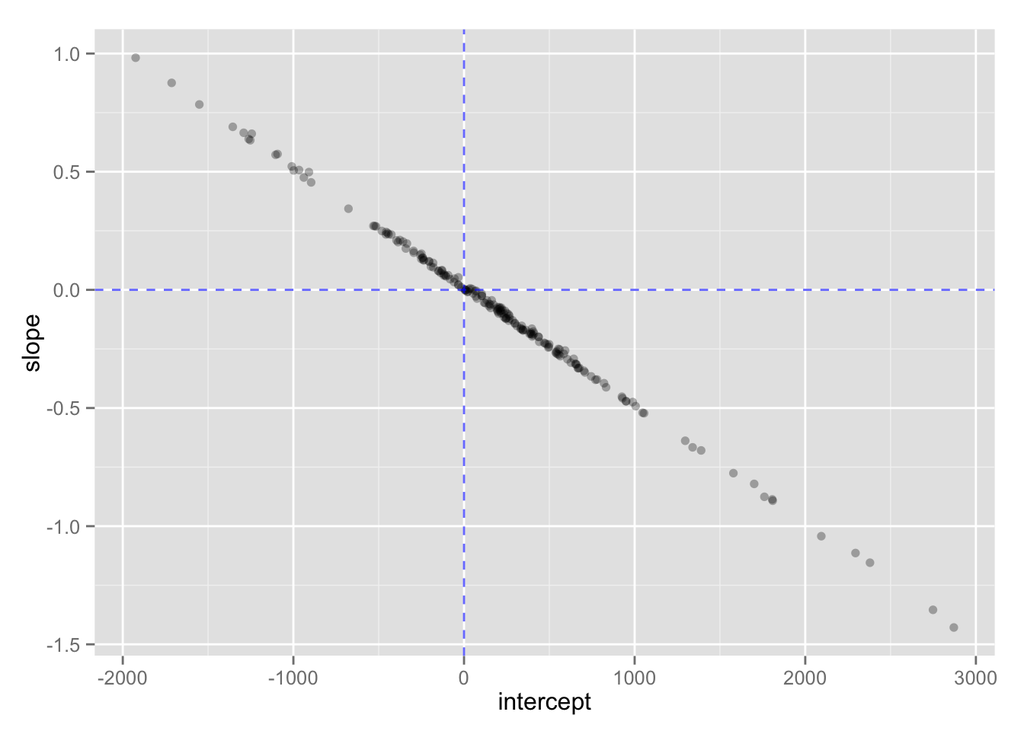

```r
tmp <- with(ldf,
            by(ldf, country,
               function(x) lm(percentage ~ year_numeric, data = x)
               )
            )

ldf.lm_by_country <- as.data.frame(t(sapply(tmp, coef)))

colnames(ldf.lm_by_country) <- c('intercept','slope')

ggplot(aes(y = slope, x = intercept),
       data = ldf.lm_by_country) +
  geom_point(alpha = 3/10) +
  geom_hline(aes (yintercept=0), alpha = 6/10, color = 'blue', linetype = 2) +
  geom_vline(aes (xintercept=0), alpha = 6/10, color = 'blue', linetype = 2)
```

#### Comments:

Seems that more of the countries have a negative slope in linear model (percentage decreased over time).

### Bucketed linear model for change in percentage by country

Using linear models generated for each country

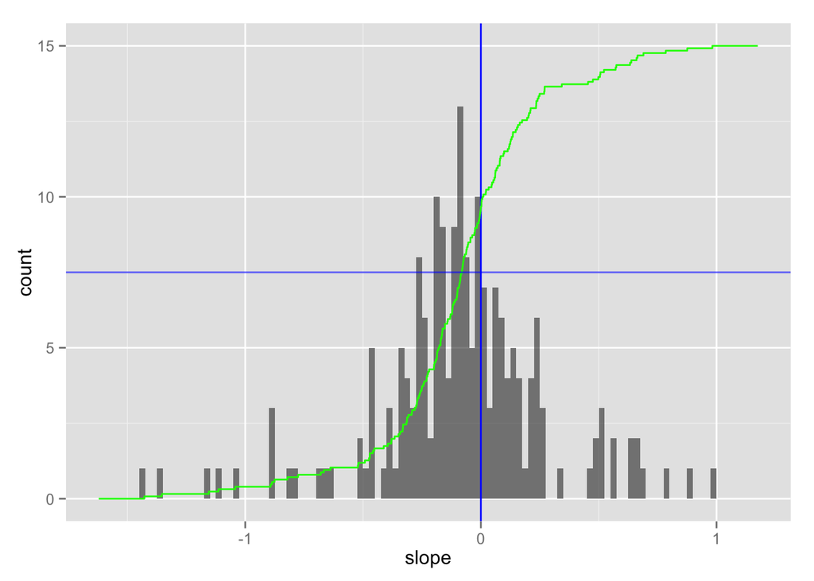

```r
## couldn't get variable to work
#cdf_height <- 15

ggplot(aes(x = slope), data = ldf.lm_by_country) +
  geom_histogram(alpha = 6/10, binwidth = 2.5/100) +
  geom_vline(aes (xintercept=0), color = 'blue') +
  geom_step(aes(len = 15, y = ..y.. * 15), stat = "ecdf", color = 'green') +
  geom_hline(aes (yintercept=15 / 2), alpha = 6/10, color = 'blue')
```

In the plot above with the CDF (cumulative distribution function) included in the histogram, it may be noted that more than half of the countries exhibited a decline (negative slope in the linear models) for the 65 years and over employment rate in the years that the observations span.

A box plot graph and numerical summary of the linear model slopes also show this (with the median value for slops being negative):

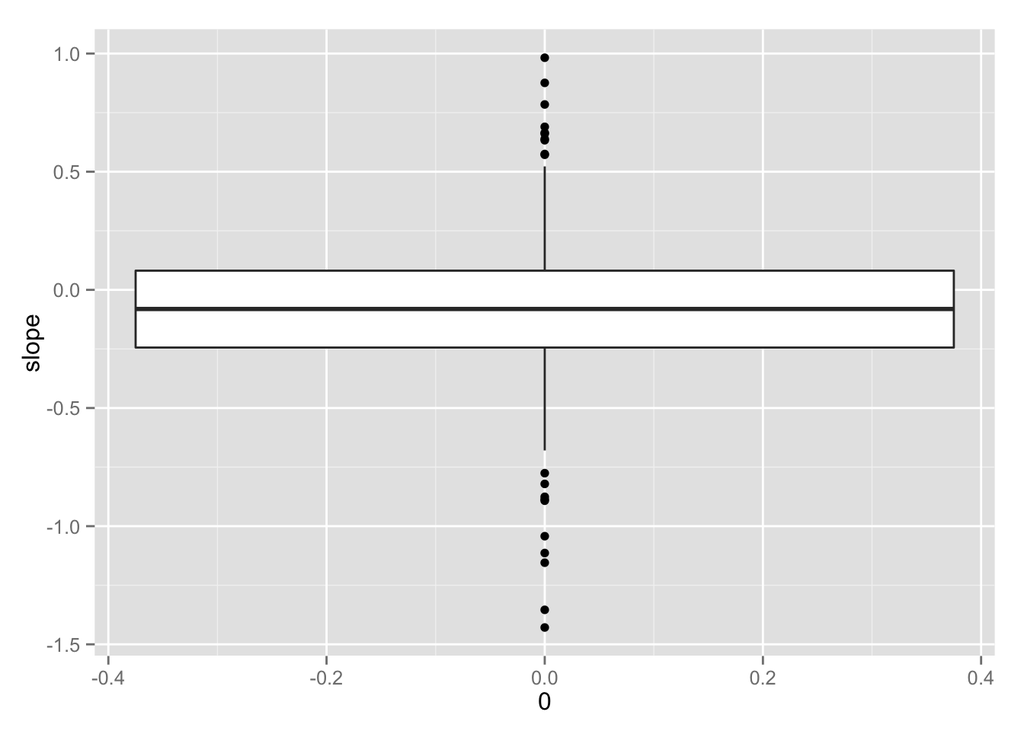

```r
ggplot(aes(x = 0, y = slope), data = ldf.lm_by_country) +
  geom_boxplot()
```

```r
summary(ldf.lm_by_country$slope)
```

```
##     Min.  1st Qu.   Median     Mean  3rd Qu.     Max.
## -1.42900 -0.24410 -0.08095 -0.08526  0.08117  0.98230
```

Next steps might be geographical region clustering analysis or weighted-by-population analysis. Each of those would require additional data to be pulled in.